# Registered Reports

[figure not shown]

# Registered Reports: Peer review before results are known to align scientific values and practices.

Registered Reports

Registered Reports is a publishing format that emphasizes the importance of the research question and the quality of methodology by conducting peer review prior to data collection. High quality protocols are then provisionally accepted for publication if the authors follow through with the registered methodology.

This format is designed to reward best practices in adhering to the hypothetico-deductive model of the scientific method. It eliminates a variety of questionable research practices, including low statistical power, selective reporting of results, and publication bias, while allowing complete flexibility to report serendipitous findings.

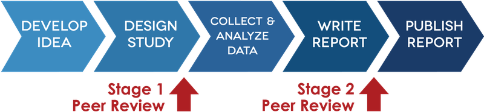

*“Registered Reports eliminates the bias against negative results in publishing because the results are not known at the time of review."*

-- Daniel Simons, Professor at University of Illinois, Urbana-Champaign, co-editor of Registered Replication Reports at Perspectives on Psychological Science, and incoming chief editor of Advances in Methods and Practices in Psychological Science

*"Because the study is accepted in advance, the incentives for authors change from producing the most beautiful story to the most accurate one."*

--Chris Chambers, Professor at Cardiff University, Section Editor for Registered Reports at Cortex, European Journal of Neuroscience and Royal Society Open Science, Chair of the Registered Reports Committee supported by the Center for Open Science

These articles provide an introduction to the Registered Reports concept: an introduction to a special issue of 15 Registered Reports in Social Psychology ([Nosek & Lakens, 2014](http://psycnet.apa.org/journals/zsp/45/3/137/)), and an introduction to Registered Reports for AIMS Neuroscience including answers to 25 common questions about Registered Reports ([Chambers, Feredoes, Muthukumaraswamy, & Etchells, 2014](https://orca.cf.ac.uk/59475/1/AN2.pdf)). Chris Chambers provides a summary of how the Registered Reports initiative is making an impact in [this article in Editors' Update](https://www.elsevier.com/editors-update/story/peer-review/cortexs-registered-reports) and reflects on the progress of the format, providing a vision for the future in "[What’s next for Registered Reports?](https://www.nature.com/articles/d41586-019-02674-6)"

### **Resources**

- See a list of published Registered Reports in [this Zotero library](https://www.zotero.org/groups/osf/items/collectionKey/KEJP68G9).
- Authors or editors can register accepted, stage 1 protocols by selecting the "Registered Report Protocol Preregistration" on the [OSF Registry](https://osf.io/registries/osf/new).
- A [checklist](https://osf.io/93znh/) to help you craft an effective submission.
- "Practical Considerations for Navigating Registered Reports" by Kiyonaga and Scimeca provide a great overview for authors.
- Webinars on Registered Reports and other initiatives are archived [here](http://cos.io/our-services/webinars/).
- **[Registered Reports Now!](https://osf.io/3wct2/wiki/home/)** is an education campaign to encourage adoption, please use the language on this page to encourage policy change.
- Share this [infographic](https://osf.io/es5vu/).
- For inquiries, please contact David Mellor.

[figure not shown]

## Responsible stewards of your support

[figure not shown]